# A guide to genome QC and viz with GENESPACE

JT Lovell

2023-04-12

## 1. Overview

Starting with v1.2.0, GENESPACE offers genome quality control and visualization tools outside of the standard pipeline for syntenic orthology.

The main added functionality fall into three groups:

1. Kmer finding, parsing and plotting (e.g. telomeres, gaps)
2. Sliding window analysis of intervals (e.g. genes, repeats)
3. Contig and telomere position plotting.

## 2. Using GENESPACE for genome viz

Unlike the syntenic orthology methods, the routines here do not require any third party programs aside from a few R packages (you don’t need to install MCScanX, OrthoFinder, etc.).

However, you will need the following additional packages: `GenomicRanges`, `GenomeInfoDb`, `IRanges`, and `BiocGenerics`. These can be downloaded from Bioconductor as follows:

```r
if (!require("BiocManager", quietly = TRUE))
    install.packages("BiocManager")

BiocManager::install(
  c("BiocGenerics", "IRanges", "GenomicRanges", "GenomeInfoDb", "rtracklayer")
```

So, to get started, you can just open an R session however you would normally, install GENESPACE (if you haven’t or have a version < 1.2.0) and load it into R.

```r
if(!require("GENESPACE", quietly = TRUE)){
  devtools::install_github("jtlovell/GENESPACE", upgrade = F)
}else{
  gsv <- as.numeric(strsplit(as.character(
    packageVersion("GENESPACE")), ".", fixed = T)[[1]])
  if(gsv[1] < 1 || (gsv[1] >= 1 & gsv[2] < 2)){
    detach("package:GENESPACE", unload = TRUE)
    devtools::install_github("jtlovell/GENESPACE", upgrade = F)
  }
}
```

```
## GENESPACE v1.2.0: synteny and orthology constrained comparative
##         genomics
```

```r
library(GENESPACE)
```

For this tutorial, we also need to load a few other packages for plotting and data wrangling …

```r
suppressPackageStartupMessages(library(data.table))
suppressPackageStartupMessages(library(Biostrings))
suppressPackageStartupMessages(library(ggplot2))
```

## 3. Input data

There are three types of data that GENESPACE genome viz can handle:

1. Soft- or un-masked genome assembly fasta
2. Genomic intervals (e.g. bed or gff-formatted annotations)
3. kmer fasta files

Unlike the main GENESPACE pipeline, there is a bit of scripting that is required for viz. Specifically, you’ll need to read your source files in and get them into a format that GENESPACE likes.

Here, we’ll illustrate the functionality with the Hg38 human genomes. Specifically, we’ll make contig maps, then do sliding windows with gene and repeat gff files.

To start, make a new directory to put the files, then download them there:

```r
wd <- "~/Downloads/vizTest"
if(!dir.exists(wd))
  dir.create(wd)

gffFile <- file.path(wd, "GRCh38_latest_genomic.gff.gz")
faFile <- file.path(wd, "GRCh38_latest_genomic.fna.gz")

url <- "https://ftp.ncbi.nlm.nih.gov/refseq/H_sapiens/annotation/GRCh38_latest/refseq_identifiers/"

if(!file.exists(gffFile))
  tmp <- download.file(
    file.path(url, "GRCh38_latest_genomic.gff.gz"),
    destfile = gffFile)

if(!file.exists(faFile))
  tmp <- download.file(
    file.path(url, "GRCh38_latest_genomic.fna.gz"),
    destfile = faFile)
```

Then we can read these files into R memory. This can be a pretty big lift for some machines and some large genomes.

```r
dnaSS <- Biostrings::readDNAStringSet(faFile)
```

We also only want to show the main chromosomes (not all the unlocalized scaffolds). To drop these, we need to do a little parsing:

```r
ns <- names(dnaSS)
ns <- ns[!grepl("unlocalized|RANDOM", ns) & # drop chrs with these terms
           grepl("GRCh38.p14 Primary Assembly", ns)] # keep chrs with these
dnaSS <- dnaSS[ns]

# -- parse the chromosome names so they are better for plotting ...
names(dnaSS) <- sapply(names(dnaSS), function(x) strsplit(x, " ")[[1]][[5]])
names(dnaSS) <- gsub(",", "", names(dnaSS), fixed = T)
```

## 4. Make the contig map

- `teloKmers`: the repeated sequences that indicate the presence of a telomere. These and their reverse compliments are used.
- `maxDistBtwTelo`: the maximum distance in base pairs within a single telomere sequence between two exact matches of the telomere kmers. Larger gaps mean that the telomere is split into multiple intervals.
- `minTeloSize`: the minimum size in base pairs for a sequence to be considered a telomere
- `minTeloDens`: the minimum proportion of sequence in a telomere that exactly matches one or more of the kmers.

This function also drops small contigs/scaffolds to make visualization and summary stats clearer. To adjust this value, use `minChrSize`.

```r
humanTelomereKmers <- "TTAGGG"
genomeGrs <- find_contigsGapsTelos(
  dnass = dnaSS,
  teloKmers = humanTelomereKmers,
  maxDistBtwTelo = 500,
  minTeloSize = 100,
  minTeloDens = .9,
  maxDist2end = 50e3,
  minChrSize = 1e6,
  minContigGapSize = 1000)
```

```
##         N. scaffolds = 24 (N50 = 156.04Mb); total length = 3088.27Mb
##         N. contigs = 867 (N50 = 52.37Mb); total length = 2937.64Mb
##         N. telomeres = 5 (1.81kb) on chrs: 5L, 7LR, 18I, 21R
```

```r
print(lapply(genomeGrs, head))
```

```
## $gaps
## GRanges object with 6 ranges and 0 metadata columns:
##       seqnames            ranges strand
##          <Rle>         <IRanges>  <Rle>
##   [1]        1           1-10000      *
##   [2]        1     207667-257666      *
##   [3]        1     297969-347968      *
##   [4]        1     535989-585988      *
##   [5]        1   2702782-2746290      *
##   [6]        1 12954385-13004384      *
##   -------
##   seqinfo: 24 sequences from an unspecified genome
##
## $contigs
## GRanges object with 6 ranges and 0 metadata columns:
##       seqnames            ranges strand
##          <Rle>         <IRanges>  <Rle>
##   [1]        1      10001-207666      *
##   [2]        1     257667-297968      *
##   [3]        1     347969-535988      *
##   [4]        1    585989-2702781      *
##   [5]        1  2746291-12954384      *
##   [6]        1 13004385-16799163      *
##   -------
##   seqinfo: 24 sequences from an unspecified genome
##
## $telomeres
## GRanges object with 5 ranges and 1 metadata column:
##       seqnames              ranges strand |    position
##          <Rle>           <IRanges>  <Rle> | <character>
##   [1]        5         10004-11813      * |        left
##   [2]        7         10005-10238      * |        left
##   [3]        7 159335858-159335973      * |       right
##   [4]       18   80262893-80263281      * |       inter
##   [5]       21   46699870-46699983      * |       right
##   -------
##   seqinfo: 24 sequences from an unspecified genome
```

The reported values are for sequences in the fasta. In this case these are the chromosomes, but may also be scaffolds. Contigs are here defined as sub-sequences in the chromosomes separated by consecutive runs of >= 1,000 Ns, as specified in `minContigGapSize`. Telomeres are categories as on the right (R) or left (L) terminus if they are within `maxDist2end` of the very end of the chromosome. Here, setting this to 50kb since some chromosomes have long runs of N’s at the termini.

The output is a list of genomic ranges (GR), which can be plotted with the GENESPACE function `plot_contigs`. This can take a single contigGapTelomere (‘cgt’) or a named list of cgts to make a multi-paneled figure.

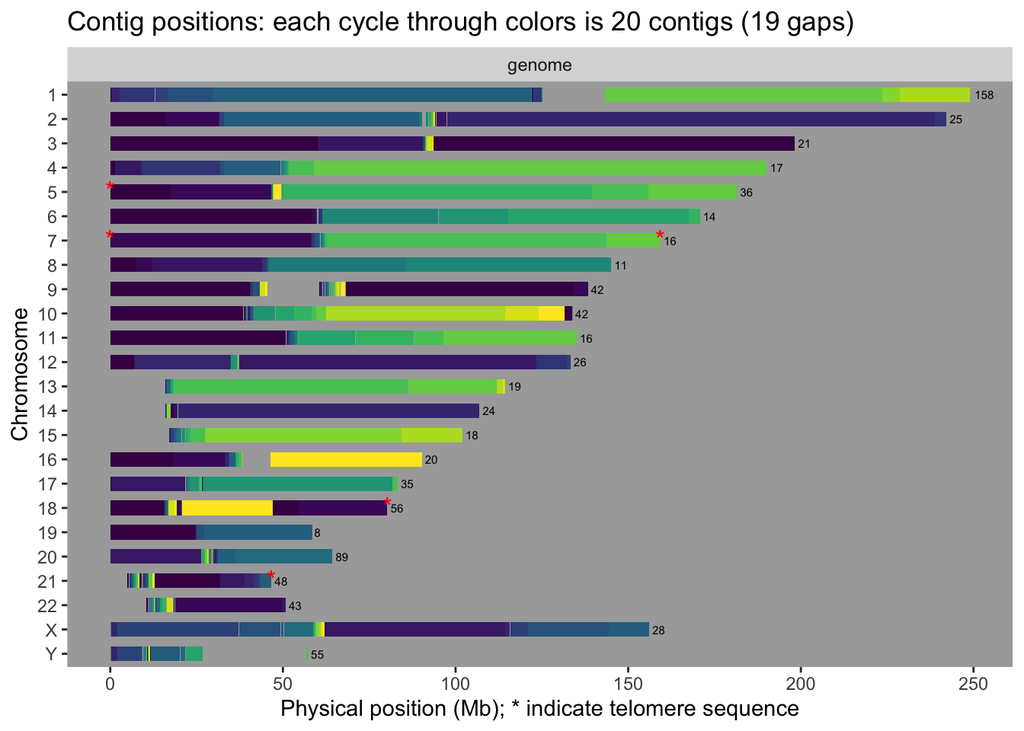

```r
plot_contigs(
  cgt = genomeGrs,
  nColors = 20,
  palette = viridis::viridis)
```

## 5. Sliding window of proportion of sequence in intervals

Sliding windows are a useful way to summarize the large and complex data stored in a genome. One standard way of presenting this data is by showing gene and repeat densities. Here, we’ll illustrate how to do this using GENESPACE functionality.

First, download the T2T annotation and assembly files:

```r
faFile <- file.path(wd, "chm13v2.0.fa.gz")
geneGffFile <- file.path(wd, "chm13v2.0_RefSeq_Liftoff_v4.gff3")
repBedFile <- file.path(wd, "chm13v2.0_RepeatMasker_4.1.2p1.2022Apr14.bed")
url <- "https://s3-us-west-2.amazonaws.com/human-pangenomics/T2T/CHM13/assemblies"

if(!file.exists(geneGffFile))
  tmp <- download.file(
    file.path(url, "annotation/chm13v2.0_RefSeq_Liftoff_v4.gff3"),
    destfile = geneGffFile)

if(!file.exists(repBedFile))
  tmp <- download.file(
    file.path(url, "annotation/chm13v2.0_RepeatMasker_4.1.2p1.2022Apr14.bed"),
    destfile = repBedFile)

if(!file.exists(faFile))
  tmp <- download.file(
    file.path(url, "analysis_set/chm13v2.0.fa.gz"),
    destfile = faFile)
```

Then, read in these data into R …

```r
dnaSS <- Biostrings::readDNAStringSet(faFile)
names(dnaSS) <- sapply(names(dnaSS), function(x) strsplit(x, " ")[[1]][1])
dnaSS <- dnaSS[Biostrings::width(dnaSS) > 1e6]
seqInfo <- pull_seqInfo(dnaSS)

genes <- as.data.frame(rtracklayer::readGFF(
  geneGffFile,
  columns = c("seqid", "start", "end", "type"),
  tags = "Parent",
  filter = list(type = c("transcript", "exon"))))
genes <- subset(genes, seqid %in% names(dnaSS))

library(data.table)
repeats <- fread(
  repBedFile,
  select = c(1:3, 7),
  col.names = c("chr", "start", "end", "type"))
repeats <- subset(repeats, chr %in% names(dnaSS))
```

Combine the datasets into a list of bed-like objects (with chr, start, end columns) …

```r
bedList <- list(
  exon = with(subset(genes, type == "exon"), data.frame(
    chr = seqid, start = start, end = end)),
  LINE.SINE = with(subset(repeats, grepl("LINE|SINE", type)), data.frame(
    chr = chr, start = start, end = end)),
  LTR = with(subset(repeats, grepl("LTR", type)), data.frame(
    chr = chr, start = start, end = end)),
  Satellite = with(subset(repeats, grepl("Satellite", type)), data.frame(
    chr = chr, start = start, end = end)),
  otherRepeat = with(subset(repeats, !grepl("LINE|SINE|Satellite|LTR", type)), data.frame(
    chr = chr, start = start, end = end)),
  introns = with(subset(genes, type == "transcript"), data.frame(
    chr = seqid, start = start, end = end)))
print(lapply(bedList, head))
```

```
## $exon
##    chr start   end
## 1 chr1  6047  6420
## 2 chr1 12078 12982
## 3 chr1 13445 13579
## 4 chr1 13680 13941
## 5 chr1 15080 15564
## 6 chr1 20566 21429
##
## $LINE.SINE
##    chr  start    end
## 1 chr1  85197  85334
## 2 chr1 182465 182534
## 3 chr1 184943 184984
## 4 chr1 199372 199439
## 5 chr1 199619 199652
## 6 chr1 307256 307426
##
## $LTR
##    chr   start     end
## 1 chr1   41543   41632
## 2 chr1 5181065 5181244
## 3 chr1 6268240 6268279
## 4 chr1 7847222 7847376
## 5 chr1 8122020 8122218
## 6 chr1 8607147 8607529
##
## $Satellite
##     chr     start       end
## 1  chr1 128597745 128602824
## 2  chr1 128602897 128603441
## 3  chr1 143252640 143252705
## 4 chr10  39181119  39181174
## 5 chr12  34284363  34284443
## 6 chr13   5142400   5145017
##
## $otherRepeat
##    chr  start    end
## 1 chr1 152485 153701
## 2 chr1 153906 156321
## 3 chr1 159491 159734
## 4 chr1 162897 163140
## 5 chr1 166313 166556
## 6 chr1 263981 264143
##
## $introns
##    chr  start    end
## 1 chr1   6047  13941
## 2 chr1  15080  21429
## 3 chr1  20529  37628
## 4 chr1  52979  54612
## 5 chr1 111940 112877
## 6 chr1 115046 117120
```

The function `classify_genome` takes this list of bed objects and hierarchically classifies the genomes in the order the bed objects are provided. So, here, first all exon sequences are found and overlapping ranges are joined. This exon sequence is then masked from the genome and the repeats regions are inferred, sequentially masking any sequence already there. Finally, un-classified sequence intervals are found.

```r
suppressWarnings(genomeClasses <- classify_genome(
  dnaSS = dnaSS, listOfBeds = bedList, verbose = T))
```

```
##  (3117.28 Mb in 24 chrs)
## Classifying the genome by 6 bed files ...
##  151.51Mb exon sequence (151.51Mb masked)
##  1012.07Mb LINE.SINE sequence (1163.58Mb masked)
##  266.57Mb LTR sequence (1430.15Mb masked)
##  157.66Mb Satellite sequence (1587.82Mb masked)
##  226.64Mb otherRepeat sequence (1814.45Mb masked)
##  766.11Mb introns sequence (2580.56Mb masked)
##  536.72Mb un-annotated sequence
```

```r
print(lapply(genomeClasses, head))
```

```
## $exon
## GRanges object with 6 ranges and 0 metadata columns:
##       seqnames      ranges strand
##          <Rle>   <IRanges>  <Rle>
##   [1]     chr1   6047-6420      *
##   [2]     chr1 12078-12982      *
##   [3]     chr1 13445-13579      *
##   [4]     chr1 13680-13941      *
##   [5]     chr1 15080-15564      *
##   [6]     chr1 20529-21429      *
##   -------
##   seqinfo: 24 sequences from an unspecified genome
##
## $LINE.SINE
## GRanges object with 6 ranges and 0 metadata columns:
##       seqnames      ranges strand
##          <Rle>   <IRanges>  <Rle>
##   [1]     chr1   4663-5263      *
##   [2]     chr1   5528-5686      *
##   [3]     chr1   6421-7132      *
##   [4]     chr1   7141-7533      *
##   [5]     chr1 10869-10972      *
##   [6]     chr1 14341-14427      *
##   -------
##   seqinfo: 24 sequences from an unspecified genome
##
## $LTR
## GRanges object with 6 ranges and 0 metadata columns:
##       seqnames      ranges strand
##          <Rle>   <IRanges>  <Rle>
##   [1]     chr1   4082-4660      *
##   [2]     chr1   5274-5527      *
##   [3]     chr1   5687-6046      *
##   [4]     chr1   8398-8840      *
##   [5]     chr1  9961-10357      *
##   [6]     chr1 11446-11644      *
##   -------
##   seqinfo: 24 sequences from an unspecified genome
##
## $Satellite
```

[output cut: 35 more lines]

```
##   -------
##   seqinfo: 24 sequences from an unspecified genome
##
## $unknown
## GRanges object with 6 ranges and 0 metadata columns:
##       seqnames      ranges strand
##          <Rle>   <IRanges>  <Rle>
##   [1]     chr1   2706-2708      *
##   [2]     chr1   4661-4662      *
##   [3]     chr1   5264-5273      *
##   [4]     chr1 14256-14340      *
##   [5]     chr1 14428-14690      *
##   [6]     chr1 14735-15079      *
##   -------
##   seqinfo: 24 sequences from an unspecified genome
```

With a hierarchical classification of the genome in hand, we can use `slide_genome` to ask about the relative abundance of each class in a given window.

```r
sws <- slide_genome(
  seqInfo = seqInfo,
  listOfGrs = genomeClasses[c(1,6,7,2,3,4,5)],
  windowSize = 5e6,
  stepSize = 1e6)
head(sws)
```

```
##     chr start     end     nBp        id nBpWindow  propWind   cumProp
## 1: chr1     1 5000000  533430      exon     5e+06 0.1066860 0.1066860
## 2: chr1     1 5000000 1504354   introns     5e+06 0.3008708 0.4075568
## 3: chr1     1 5000000 1089047   unknown     5e+06 0.2178094 0.6253662
## 4: chr1     1 5000000 1045929 LINE.SINE     5e+06 0.2091858 0.8345520
## 5: chr1     1 5000000  429087       LTR     5e+06 0.0858174 0.9203694
## 6: chr1     1 5000000    2696 Satellite     5e+06 0.0005392 0.9209086
```

The output data.table (see above) can then be easily plotted in ggplot2 using `geom_area`.

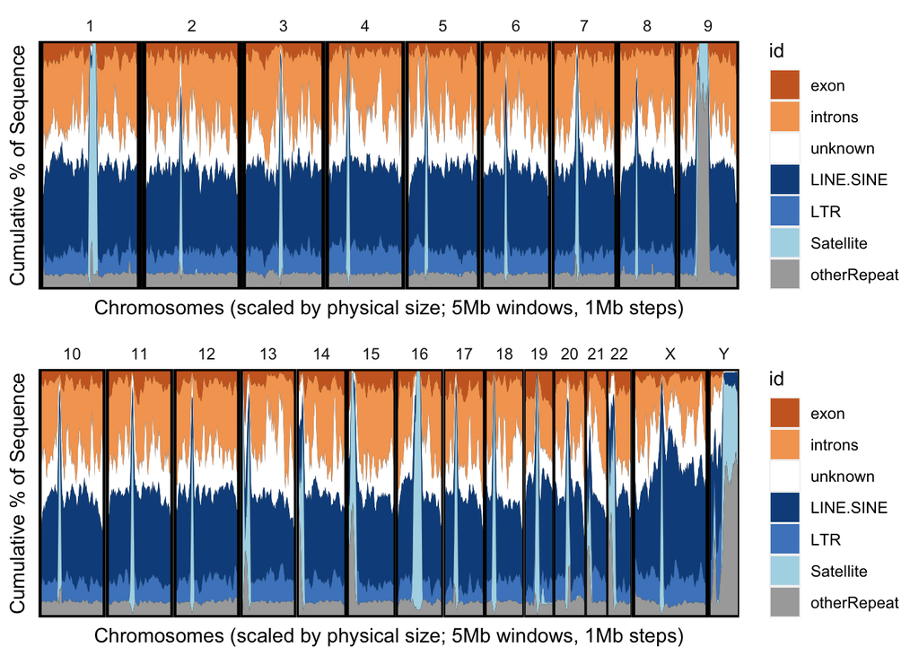

```r
library(ggplot2)
plotCols <- c("#CC6828", "#F4A460", "#FFFFFF", "#0F4F8B", "#4C86C6", "#AED8E6", "darkgrey")
plotTheme <- theme(
  panel.background = element_rect(fill = "black"),
  panel.border = element_blank(),
  panel.grid = element_blank(),
  axis.ticks = element_blank(),
  axis.text = element_blank(),
  panel.spacing = unit(0, "cm"),
  strip.background = element_blank())

p1 <- ggplot(subset(sws, chr %in% sprintf("chr%s", 1:9)),
             aes(x = start/1e6, y = propWind, fill = id))+
  geom_area()+
  scale_fill_manual(values = plotCols) +
  facet_grid(.~ gsub("chr","",chr), scale = "free", space = "free") +
  scale_x_continuous(expand = c(0.05,0.05))+
  scale_y_continuous(expand = c(0.005,0.005))+
  plotTheme +
  labs(x = "Chromosomes (scaled by physical size; 5Mb windows, 1Mb steps)",
       y = "Cumulative % of Sequence")
p2 <- ggplot(subset(sws, !chr %in% sprintf("chr%s", 1:9)),
             aes(x = start/1e6, y = propWind, fill = id))+
  geom_area()+
  scale_fill_manual(values = plotCols) +
  facet_grid(.~gsub("chr","",chr), scale = "free", space = "free") +
  scale_x_continuous(expand = c(0.05,0.05))+
  scale_y_continuous(expand = c(0.005,0.005))+
  plotTheme +
  labs(x = "Chromosomes (scaled by physical size; 5Mb windows, 1Mb steps)",
       y = "Cumulative % of Sequence")
gridExtra::grid.arrange(p1, p2, nrow = 2)
```